# Exploration of Red Wine data by Prayag

# Multivariate Analysis

### Some of the relationships you observed in this part of the investigation.

Comparing with sulphates with alcohol content by quality, we see that higher amounts of sulphates combined with higher concentrations of alcohol tends to get higher quality ratings.

### OPTIONAL: Did you create any models with your dataset? Discuss the strengths and limitations of your model.

Yes, I created a simple predictive model based upon the analysis in the previous sections. With coefficient plots we saw how these coefficients interact with one another and drives the prediction. At the end we randomly picked the data from original data source and tried to see how well the model predicts and it came very close to the actual ratings.

# Final Plots and Summary

### Plot One

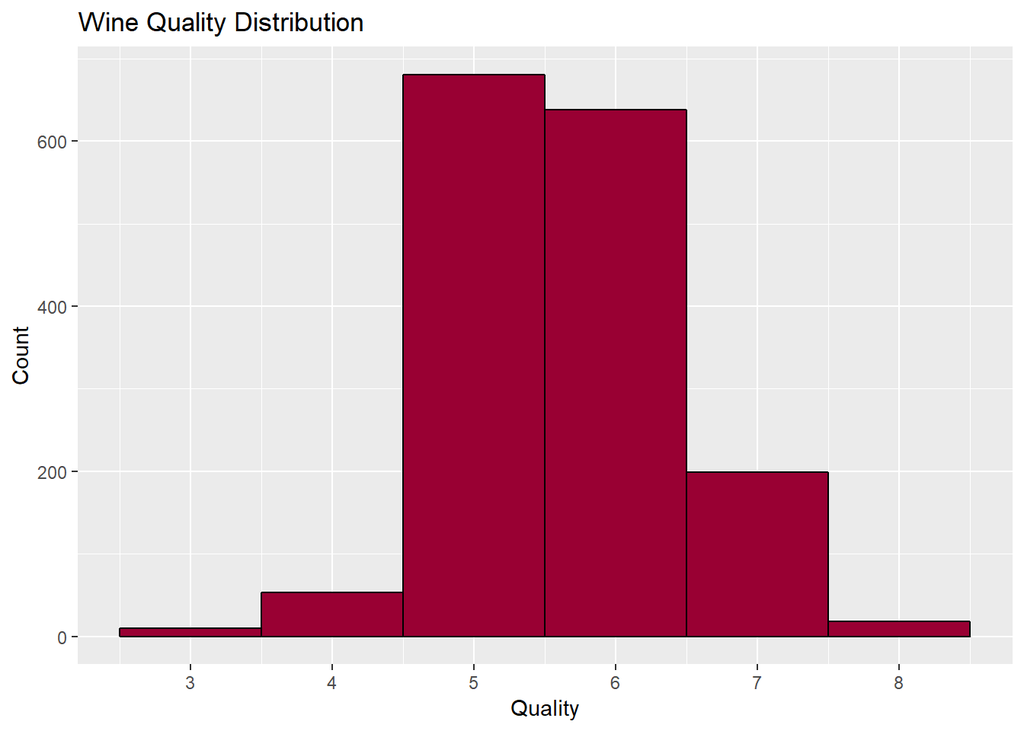

### Description One

This plot is gives the first and foremost insight into our dataset. The distribution of wine quality ratings (scale 0 to 10) is more or less normal. It seems that experts are neither too liberal nor to conservative when judging a red wine. From the dataset, no wine got quality ratings of 1 or 2 while relatively few wines got ratings of 3 and 4. About 80% of the wines got quality rating of 5 or 6 - medium. Only 18 wines from the dataset got the highest quality rating of 8. No wines received 9 or 10 rating.

### Plot Two

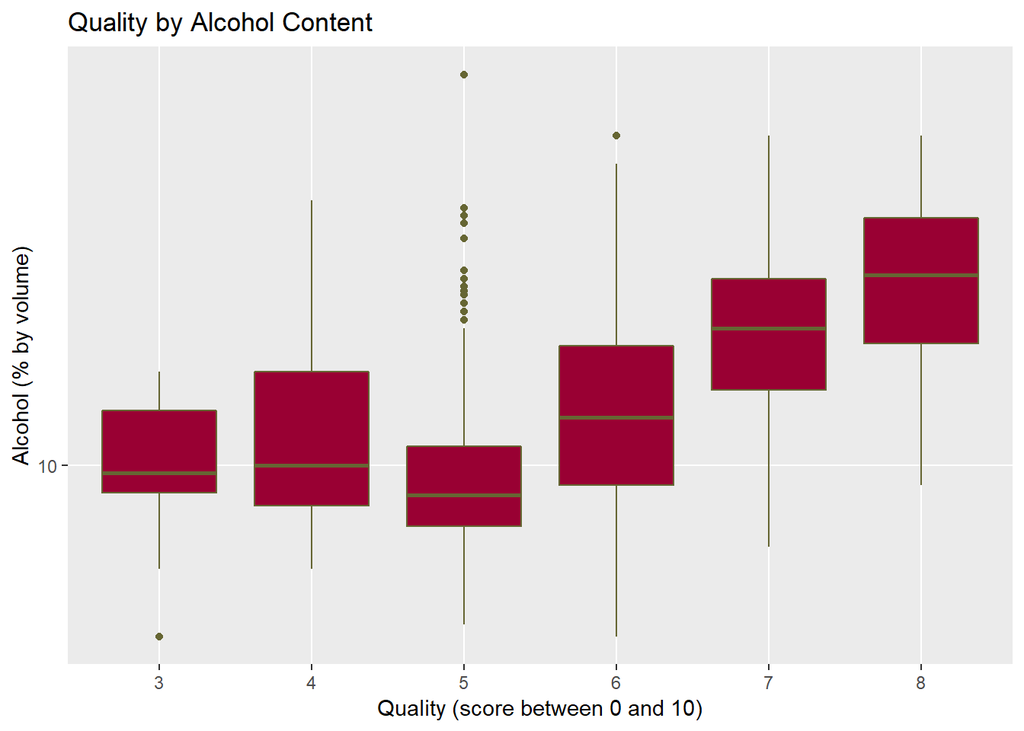

### Description Two

The plot is by far the most revealing. The higher alcohol content tends to receive higher quality ratings from the ‘experts’! The box plot reveals the gradual increase in the quality along with the increamental percentage of alcohol. Although quality 3 and 4 have slightly higher alcohol content with respect to quality 5, rest quality factors have clear increase.

### Plot Three

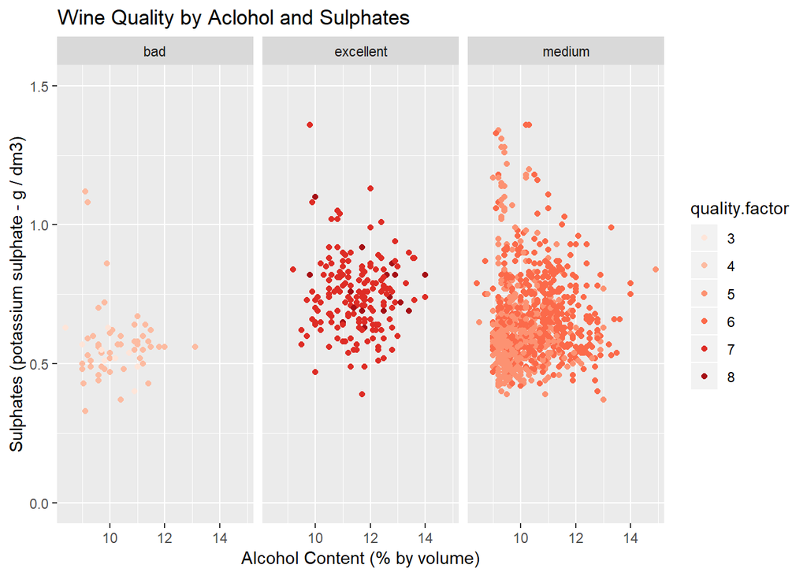

### Description Three

Comparing with sulphates with alcohol content by quality, we see that higher amounts of sulphates combined with higher concentrations of alcohol tends to get higher quality ratings. For bad quality wines the alcohol content is almost between the range of 9 and 12 and sulphates between 0.3 and 0.7. Low indeed in comparison. Some of the medium quality wines do have lower alcohol content but those points have relatively higher sulphate content. The excellent quality wines have relatively even spread on both the axis with some exception.

# Reflection

In the above parts, we explored the Red Wine quality ratings given by experts along with some chemical properties observed in studies.

We started off by exploring the distribution of ratings. The expert opinion on quality is fairly concentrated on medium ratings. None of the experts gave ratings lower than 3 or higher than 8. Even then, relatively low number of samples received lower or higher ratings. The distributions of most of the variables were normal except for few. Interestingly volatile acidity showed bimodal distribution and citric acid has a high peak at zero.

In the bivariate section, we explored how two variables interact with one another. Surprisingly the alcohol makes everything better. The wines that received higher quality ratings had higher alcohol contents. Also, how sulphates and quality were intertwined. It goes without saying that the acidity related variables had, of course, higher correlation coefficients.

At the end, we explored multiple variables and their interaction to one another. It was evident that density did not play much of a role in determining the quality. But on the other hand, given the direct correlation of density to alcohol, it was worth exploring. When added to the linear model and plotting the coefficients of the model, it became evident that density plays a tiny bit of role in predicting the quality. When cross referencing the predicted values with random sample from original dataset, we got a very close value of the fir to the actual quality rating.

However, none of the parameters except for alcohol stood out deterministically. This can be the effect of personal preference. These ratings were given by experts based on sensory feelings. In such case, a-priory information, prejudice, personal preference etc. play a big role and brings in a certain level of unpredictibiltiy in the judgements.

The analysis of red wines was all about exploring the data and get the feel for it. The most difficult part for me was to ensure that no relationship is left unexplored. The ggpair plots and coefficient plots gave a good sense of understanding of the relationships between variables. The dataset itself could have been richer in terms of variables and data points to infer more out of it. Perhaps more data from different sources can be attached to this set in order to open up the possibility of inferring more. Although, the predictive model we created did a pretty decent job for randomly chosen points.